# Risk Factor Analysis

## Outcome Variable

**Outcome Variable:** ever_wasted

## Predictor Variables

**Intervention Variable:** feducyrs

**Adjustment Set:**

- arm
- W_mage
- meducyrs
- hhwealth_quart
- W_mhtcm
- W_mwtkg
- W_mbmi
- W_gagebrth
- W_birthwt
- W_birthlen
- single
- delta_W_mage
- delta_meducyrs
- delta_hhwealth_quart
- delta_W_mhtcm
- delta_W_mwtkg
- delta_W_mbmi
- delta_W_gagebrth
- delta_W_birthwt
- delta_W_birthlen
- delta_single

## Stratifying Variables

The analysis was stratified on these variable(s):

- agecat
- studyid
- country

## Data Summary

| agecat | studyid | country | feducyrs | ever_wasted | n_cell | n |
| --- | --- | --- | --- | --- | --- | --- |
| 0-24 months | COHORTS | GUATEMALA | High | 0 | 164 | 1234 |
| 0-24 months | COHORTS | GUATEMALA | High | 1 | 67 | 1234 |
| 0-24 months | COHORTS | GUATEMALA | Low | 0 | 419 | 1234 |
| 0-24 months | COHORTS | GUATEMALA | Low | 1 | 139 | 1234 |
| 0-24 months | COHORTS | GUATEMALA | Medium | 0 | 330 | 1234 |
| 0-24 months | COHORTS | GUATEMALA | Medium | 1 | 115 | 1234 |
| 0-24 months | COHORTS | INDIA | High | 0 | 386 | 1447 |
| 0-24 months | COHORTS | INDIA | High | 1 | 181 | 1447 |
| 0-24 months | COHORTS | INDIA | Low | 0 | 305 | 1447 |
| 0-24 months | COHORTS | INDIA | Low | 1 | 167 | 1447 |
| 0-24 months | COHORTS | INDIA | Medium | 0 | 269 | 1447 |
| 0-24 months | COHORTS | INDIA | Medium | 1 | 139 | 1447 |
| 0-24 months | COHORTS | PHILIPPINES | High | 0 | 640 | 2868 |
| 0-24 months | COHORTS | PHILIPPINES | High | 1 | 388 | 2868 |
| 0-24 months | COHORTS | PHILIPPINES | Low | 0 | 480 | 2868 |
| 0-24 months | COHORTS | PHILIPPINES | Low | 1 | 346 | 2868 |
| 0-24 months | COHORTS | PHILIPPINES | Medium | 0 | 597 | 2868 |
| 0-24 months | COHORTS | PHILIPPINES | Medium | 1 | 417 | 2868 |
| 0-24 months | GMS-Nepal | NEPAL | High | 0 | 65 | 684 |
| 0-24 months | GMS-Nepal | NEPAL | High | 1 | 104 | 684 |
| 0-24 months | GMS-Nepal | NEPAL | Low | 0 | 115 | 684 |
| 0-24 months | GMS-Nepal | NEPAL | Low | 1 | 177 | 684 |
| 0-24 months | GMS-Nepal | NEPAL | Medium | 0 | 100 | 684 |
| 0-24 months | GMS-Nepal | NEPAL | Medium | 1 | 123 | 684 |
| 0-24 months | JiVitA-3 | BANGLADESH | High | 0 | 4908 | 25970 |
| 0-24 months | JiVitA-3 | BANGLADESH | High | 1 | 1569 | 25970 |
| 0-24 months | JiVitA-3 | BANGLADESH | Low | 0 | 7799 | 25970 |
| 0-24 months | JiVitA-3 | BANGLADESH | Low | 1 | 2838 | 25970 |
| 0-24 months | JiVitA-3 | BANGLADESH | Medium | 0 | 6580 | 25970 |
| 0-24 months | JiVitA-3 | BANGLADESH | Medium | 1 | 2276 | 25970 |

[output cut: 330 more lines]

The following strata were considered:

- agecat: 0-24 months, studyid: COHORTS, country: GUATEMALA
- agecat: 0-24 months, studyid: COHORTS, country: INDIA
- agecat: 0-24 months, studyid: COHORTS, country: PHILIPPINES
- agecat: 0-24 months, studyid: GMS-Nepal, country: NEPAL
- agecat: 0-24 months, studyid: JiVitA-3, country: BANGLADESH
- agecat: 0-24 months, studyid: JiVitA-4, country: BANGLADESH
- agecat: 0-24 months, studyid: LCNI-5, country: MALAWI
- agecat: 0-24 months, studyid: MAL-ED, country: BANGLADESH
- agecat: 0-24 months, studyid: MAL-ED, country: INDIA
- agecat: 0-24 months, studyid: MAL-ED, country: NEPAL
- agecat: 0-24 months, studyid: MAL-ED, country: PERU
- agecat: 0-24 months, studyid: MAL-ED, country: SOUTH AFRICA
- agecat: 0-24 months, studyid: MAL-ED, country: TANZANIA, UNITED REPUBLIC OF
- agecat: 0-24 months, studyid: NIH-Crypto, country: BANGLADESH
- agecat: 0-24 months, studyid: PROBIT, country: BELARUS
- agecat: 0-24 months, studyid: PROVIDE, country: BANGLADESH
- agecat: 0-24 months, studyid: SAS-CompFeed, country: INDIA
- agecat: 0-24 months, studyid: SAS-FoodSuppl, country: INDIA
- agecat: 0-24 months, studyid: TanzaniaChild2, country: TANZANIA, UNITED REPUBLIC OF
- agecat: 0-24 months, studyid: ZVITAMBO, country: ZIMBABWE
- agecat: 0-6 months, studyid: COHORTS, country: GUATEMALA
- agecat: 0-6 months, studyid: COHORTS, country: INDIA
- agecat: 0-6 months, studyid: COHORTS, country: PHILIPPINES
- agecat: 0-6 months, studyid: GMS-Nepal, country: NEPAL
- agecat: 0-6 months, studyid: JiVitA-3, country: BANGLADESH
- agecat: 0-6 months, studyid: JiVitA-4, country: BANGLADESH
- agecat: 0-6 months, studyid: LCNI-5, country: MALAWI
- agecat: 0-6 months, studyid: MAL-ED, country: BANGLADESH
- agecat: 0-6 months, studyid: MAL-ED, country: INDIA
- agecat: 0-6 months, studyid: MAL-ED, country: NEPAL
- agecat: 0-6 months, studyid: MAL-ED, country: PERU
- agecat: 0-6 months, studyid: MAL-ED, country: SOUTH AFRICA
- agecat: 0-6 months, studyid: MAL-ED, country: TANZANIA, UNITED REPUBLIC OF
- agecat: 0-6 months, studyid: NIH-Crypto, country: BANGLADESH
- agecat: 0-6 months, studyid: PROBIT, country: BELARUS
- agecat: 0-6 months, studyid: PROVIDE, country: BANGLADESH
- agecat: 0-6 months, studyid: SAS-CompFeed, country: INDIA
- agecat: 0-6 months, studyid: SAS-FoodSuppl, country: INDIA
- agecat: 0-6 months, studyid: TanzaniaChild2, country: TANZANIA, UNITED REPUBLIC OF
- agecat: 0-6 months, studyid: ZVITAMBO, country: ZIMBABWE
- agecat: 6-24 months, studyid: COHORTS, country: GUATEMALA
- agecat: 6-24 months, studyid: COHORTS, country: INDIA
- agecat: 6-24 months, studyid: COHORTS, country: PHILIPPINES
- agecat: 6-24 months, studyid: GMS-Nepal, country: NEPAL
- agecat: 6-24 months, studyid: JiVitA-3, country: BANGLADESH
- agecat: 6-24 months, studyid: JiVitA-4, country: BANGLADESH
- agecat: 6-24 months, studyid: LCNI-5, country: MALAWI
- agecat: 6-24 months, studyid: MAL-ED, country: BANGLADESH
- agecat: 6-24 months, studyid: MAL-ED, country: INDIA
- agecat: 6-24 months, studyid: MAL-ED, country: NEPAL
- agecat: 6-24 months, studyid: MAL-ED, country: PERU
- agecat: 6-24 months, studyid: MAL-ED, country: SOUTH AFRICA
- agecat: 6-24 months, studyid: MAL-ED, country: TANZANIA, UNITED REPUBLIC OF
- agecat: 6-24 months, studyid: NIH-Crypto, country: BANGLADESH
- agecat: 6-24 months, studyid: PROBIT, country: BELARUS
- agecat: 6-24 months, studyid: PROVIDE, country: BANGLADESH
- agecat: 6-24 months, studyid: SAS-CompFeed, country: INDIA
- agecat: 6-24 months, studyid: SAS-FoodSuppl, country: INDIA
- agecat: 6-24 months, studyid: TanzaniaChild2, country: TANZANIA, UNITED REPUBLIC OF
- agecat: 6-24 months, studyid: ZVITAMBO, country: ZIMBABWE

### Dropped Strata

Some strata were dropped due to rare outcomes:

- agecat: 0-24 months, studyid: MAL-ED, country: PERU
- agecat: 0-24 months, studyid: MAL-ED, country: TANZANIA, UNITED REPUBLIC OF
- agecat: 0-6 months, studyid: LCNI-5, country: MALAWI
- agecat: 0-6 months, studyid: MAL-ED, country: NEPAL
- agecat: 0-6 months, studyid: MAL-ED, country: PERU
- agecat: 0-6 months, studyid: MAL-ED, country: SOUTH AFRICA
- agecat: 0-6 months, studyid: MAL-ED, country: TANZANIA, UNITED REPUBLIC OF
- agecat: 6-24 months, studyid: MAL-ED, country: NEPAL
- agecat: 6-24 months, studyid: MAL-ED, country: PERU
- agecat: 6-24 months, studyid: MAL-ED, country: SOUTH AFRICA
- agecat: 6-24 months, studyid: MAL-ED, country: TANZANIA, UNITED REPUBLIC OF

## Methods Detail

We’re interested in the causal parameters $E[Y_a]$ for all values of $a \in \mathcal{A}$. These parameters represent the mean outcome if, possibly contrary to fact, we intervened to set all units to have $A=a$. Under the randomization and positivity assumptions, these are identified by the statistical parameters $\psi_a=E_W[E_{Y|A,W}(Y|A=a,W)]$. In addition, we’re interested in the mean of $Y$, $E[Y]$ under no intervention (the observed mean). We will estimate these parameters by using SuperLearner to fit the relevant likelihood factors – $E_{Y|A,W}(Y|A=a,W)$ and $p(A=a|W)$, and then updating our likelihood fit using a joint TMLE.

For unadjusted analyses ($W=\{\}$), initial likelihoods were estimated using Lrnr_glm to estimate the simple $E(Y|A)$ and Lrnr_mean to estimate $p(A)$. For adjusted analyses, a small library containing Lrnr_glmnet, Lrnr_xgboost, and Lrnr_mean was used.

Having estimated these parameters, we will then use the delta method to estimate relative risks and attributable risks relative to a prespecified baseline level of $A$.

# Results Detail

## Results Plots

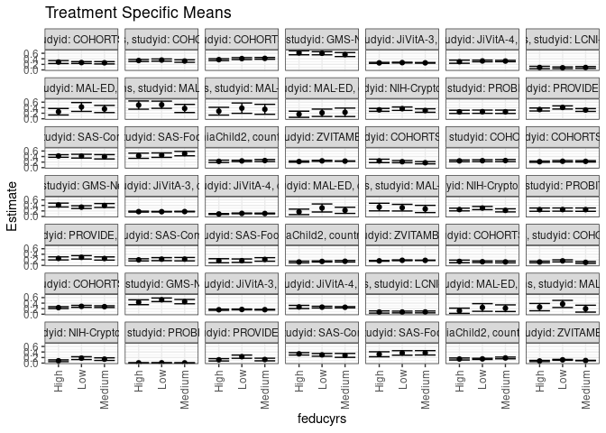

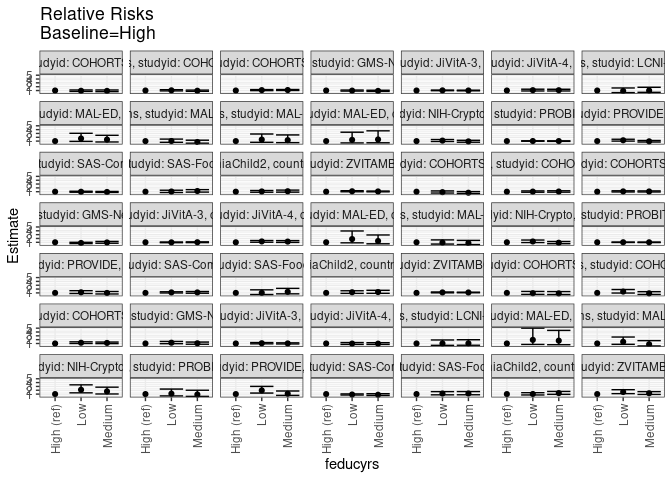

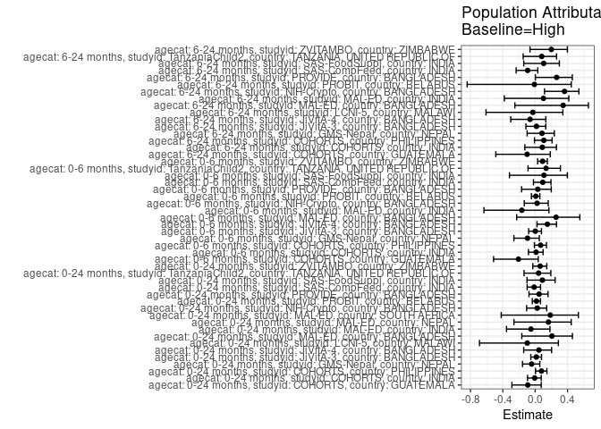

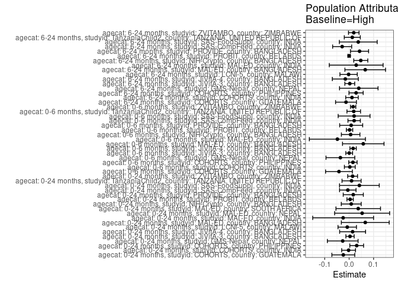

## Results Table

### Parameter: TSM

| agecat | studyid | country | intervention_level | baseline_level | estimate | ci_lower | ci_upper |
| --- | --- | --- | --- | --- | --- | --- | --- |
| 0-24 months | COHORTS | GUATEMALA | High | NA | 0.2839805 | 0.2313864 | 0.3365746 |
| 0-24 months | COHORTS | GUATEMALA | Low | NA | 0.2650086 | 0.2315237 | 0.2984935 |
| 0-24 months | COHORTS | GUATEMALA | Medium | NA | 0.2570972 | 0.2158600 | 0.2983344 |
| 0-24 months | COHORTS | INDIA | High | NA | 0.3388277 | 0.3018766 | 0.3757788 |
| 0-24 months | COHORTS | INDIA | Low | NA | 0.3552141 | 0.3154549 | 0.3949733 |
| 0-24 months | COHORTS | INDIA | Medium | NA | 0.3205796 | 0.2762283 | 0.3649309 |
| 0-24 months | COHORTS | PHILIPPINES | High | NA | 0.3704275 | 0.3375708 | 0.4032842 |
| 0-24 months | COHORTS | PHILIPPINES | Low | NA | 0.4083766 | 0.3739750 | 0.4427783 |
| 0-24 months | COHORTS | PHILIPPINES | Medium | NA | 0.4161530 | 0.3843949 | 0.4479111 |
| 0-24 months | GMS-Nepal | NEPAL | High | NA | 0.6169414 | 0.5457299 | 0.6881529 |
| 0-24 months | GMS-Nepal | NEPAL | Low | NA | 0.6018028 | 0.5452715 | 0.6583340 |
| 0-24 months | GMS-Nepal | NEPAL | Medium | NA | 0.5542398 | 0.4819513 | 0.6265284 |
| 0-24 months | JiVitA-3 | BANGLADESH | High | NA | 0.2537265 | 0.2357837 | 0.2716693 |
| 0-24 months | JiVitA-3 | BANGLADESH | Low | NA | 0.2628994 | 0.2492906 | 0.2765081 |
| 0-24 months | JiVitA-3 | BANGLADESH | Medium | NA | 0.2551850 | 0.2435862 | 0.2667838 |
| 0-24 months | JiVitA-4 | BANGLADESH | High | NA | 0.2958830 | 0.2394541 | 0.3523118 |
| 0-24 months | JiVitA-4 | BANGLADESH | Low | NA | 0.3229301 | 0.2931837 | 0.3526766 |
| 0-24 months | JiVitA-4 | BANGLADESH | Medium | NA | 0.3194405 | 0.2949919 | 0.3438891 |
| 0-24 months | LCNI-5 | MALAWI | High | NA | 0.0877765 | 0.0449090 | 0.1306440 |
| 0-24 months | LCNI-5 | MALAWI | Low | NA | 0.0776270 | 0.0459947 | 0.1092593 |
| 0-24 months | LCNI-5 | MALAWI | Medium | NA | 0.0871828 | 0.0536395 | 0.1207261 |
| 0-24 months | MAL-ED | BANGLADESH | High | NA | 0.2537027 | 0.1367308 | 0.3706745 |
| 0-24 months | MAL-ED | BANGLADESH | Low | NA | 0.4255521 | 0.2655532 | 0.5855510 |
| 0-24 months | MAL-ED | BANGLADESH | Medium | NA | 0.3541213 | 0.2251255 | 0.4831172 |
| 0-24 months | MAL-ED | INDIA | High | NA | 0.4939623 | 0.3456385 | 0.6422862 |
| 0-24 months | MAL-ED | INDIA | Low | NA | 0.5063765 | 0.3763909 | 0.6363622 |
| 0-24 months | MAL-ED | INDIA | Medium | NA | 0.3728019 | 0.2253410 | 0.5202627 |
| 0-24 months | MAL-ED | NEPAL | High | NA | 0.2733570 | 0.1334986 | 0.4132154 |
| 0-24 months | MAL-ED | NEPAL | Low | NA | 0.3833500 | 0.1965392 | 0.5701608 |
| 0-24 months | MAL-ED | NEPAL | Medium | NA | 0.3421658 | 0.1620774 | 0.5222543 |

[output cut: 117 more lines]

### Parameter: E(Y)

| agecat | studyid | country | intervention_level | baseline_level | estimate | ci_lower | ci_upper |
| --- | --- | --- | --- | --- | --- | --- | --- |
| 0-24 months | COHORTS | GUATEMALA | NA | NA | 0.2601297 | 0.2356425 | 0.2846169 |
| 0-24 months | COHORTS | INDIA | NA | NA | 0.3365584 | 0.3122030 | 0.3609138 |
| 0-24 months | COHORTS | PHILIPPINES | NA | NA | 0.4013250 | 0.3833827 | 0.4192673 |
| 0-24 months | GMS-Nepal | NEPAL | NA | NA | 0.5906433 | 0.5537666 | 0.6275199 |
| 0-24 months | JiVitA-3 | BANGLADESH | NA | NA | 0.2573354 | 0.2507501 | 0.2639207 |
| 0-24 months | JiVitA-4 | BANGLADESH | NA | NA | 0.3100246 | 0.2953385 | 0.3247108 |
| 0-24 months | LCNI-5 | MALAWI | NA | NA | 0.0799508 | 0.0612962 | 0.0986054 |
| 0-24 months | MAL-ED | BANGLADESH | NA | NA | 0.3197279 | 0.2440789 | 0.3953769 |
| 0-24 months | MAL-ED | INDIA | NA | NA | 0.4693878 | 0.3884360 | 0.5503395 |
| 0-24 months | MAL-ED | NEPAL | NA | NA | 0.3265306 | 0.2332088 | 0.4198524 |
| 0-24 months | MAL-ED | SOUTH AFRICA | NA | NA | 0.2000000 | 0.1249078 | 0.2750922 |
| 0-24 months | NIH-Crypto | BANGLADESH | NA | NA | 0.3298153 | 0.2963239 | 0.3633067 |
| 0-24 months | PROBIT | BELARUS | NA | NA | 0.2539381 | 0.1952340 | 0.3126422 |
| 0-24 months | PROVIDE | BANGLADESH | NA | NA | 0.3514286 | 0.3160364 | 0.3868207 |
| 0-24 months | SAS-CompFeed | INDIA | NA | NA | 0.4145695 | 0.3576236 | 0.4715155 |
| 0-24 months | SAS-FoodSuppl | INDIA | NA | NA | 0.4712919 | 0.4233811 | 0.5192026 |
| 0-24 months | TanzaniaChild2 | TANZANIA, UNITED REPUBLIC OF | NA | NA | 0.2366765 | 0.2196074 | 0.2537455 |
| 0-24 months | ZVITAMBO | ZIMBABWE | NA | NA | 0.2337854 | 0.2266636 | 0.2409072 |
| 0-6 months | COHORTS | GUATEMALA | NA | NA | 0.2006018 | 0.1757323 | 0.2254713 |
| 0-6 months | COHORTS | INDIA | NA | NA | 0.2462950 | 0.2238538 | 0.2687361 |
| 0-6 months | COHORTS | PHILIPPINES | NA | NA | 0.2291594 | 0.2137721 | 0.2445467 |
| 0-6 months | GMS-Nepal | NEPAL | NA | NA | 0.3771930 | 0.3408437 | 0.4135423 |
| 0-6 months | JiVitA-3 | BANGLADESH | NA | NA | 0.1757592 | 0.1700164 | 0.1815020 |
| 0-6 months | JiVitA-4 | BANGLADESH | NA | NA | 0.1079224 | 0.0978937 | 0.1179511 |
| 0-6 months | MAL-ED | BANGLADESH | NA | NA | 0.2244898 | 0.1568093 | 0.2921703 |
| 0-6 months | MAL-ED | INDIA | NA | NA | 0.2925170 | 0.2187257 | 0.3663083 |
| 0-6 months | NIH-Crypto | BANGLADESH | NA | NA | 0.2572559 | 0.2261171 | 0.2883948 |
| 0-6 months | PROBIT | BELARUS | NA | NA | 0.2485900 | 0.1897185 | 0.3074615 |
| 0-6 months | PROVIDE | BANGLADESH | NA | NA | 0.2585714 | 0.2261125 | 0.2910304 |
| 0-6 months | SAS-CompFeed | INDIA | NA | NA | 0.2197071 | 0.1750081 | 0.2644060 |
| 0-6 months | SAS-FoodSuppl | INDIA | NA | NA | 0.1866029 | 0.1492099 | 0.2239959 |
| 0-6 months | TanzaniaChild2 | TANZANIA, UNITED REPUBLIC OF | NA | NA | 0.1397398 | 0.1258162 | 0.1536634 |
| 0-6 months | ZVITAMBO | ZIMBABWE | NA | NA | 0.1794777 | 0.1729988 | 0.1859566 |
| 6-24 months | COHORTS | GUATEMALA | NA | NA | 0.1288889 | 0.1093000 | 0.1484778 |
| 6-24 months | COHORTS | INDIA | NA | NA | 0.1323843 | 0.1146569 | 0.1501118 |
| 6-24 months | COHORTS | PHILIPPINES | NA | NA | 0.2666667 | 0.2498425 | 0.2834908 |
| 6-24 months | GMS-Nepal | NEPAL | NA | NA | 0.4719864 | 0.4316361 | 0.5123367 |
| 6-24 months | JiVitA-3 | BANGLADESH | NA | NA | 0.1643382 | 0.1581062 | 0.1705701 |
| 6-24 months | JiVitA-4 | BANGLADESH | NA | NA | 0.2467286 | 0.2329282 | 0.2605290 |
| 6-24 months | LCNI-5 | MALAWI | NA | NA | 0.0773067 | 0.0588111 | 0.0958024 |
| 6-24 months | MAL-ED | BANGLADESH | NA | NA | 0.1908397 | 0.1232893 | 0.2583901 |
| 6-24 months | MAL-ED | INDIA | NA | NA | 0.2846715 | 0.2088306 | 0.3605124 |
| 6-24 months | NIH-Crypto | BANGLADESH | NA | NA | 0.1315068 | 0.1069744 | 0.1560393 |
| 6-24 months | PROBIT | BELARUS | NA | NA | 0.0083609 | 0.0045540 | 0.0121678 |
| 6-24 months | PROVIDE | BANGLADESH | NA | NA | 0.1609756 | 0.1319065 | 0.1900447 |
| 6-24 months | SAS-CompFeed | INDIA | NA | NA | 0.3051948 | 0.2633957 | 0.3469939 |
| 6-24 months | SAS-FoodSuppl | INDIA | NA | NA | 0.3557214 | 0.3088651 | 0.4025777 |
| 6-24 months | TanzaniaChild2 | TANZANIA, UNITED REPUBLIC OF | NA | NA | 0.1602787 | 0.1442326 | 0.1763249 |
| 6-24 months | ZVITAMBO | ZIMBABWE | NA | NA | 0.0946306 | 0.0890328 | 0.1002285 |

### Parameter: RR

| agecat | studyid | country | intervention_level | baseline_level | estimate | ci_lower | ci_upper |
| --- | --- | --- | --- | --- | --- | --- | --- |
| 0-24 months | COHORTS | GUATEMALA | High | High | 1.0000000 | 1.0000000 | 1.000000 |
| 0-24 months | COHORTS | GUATEMALA | Low | High | 0.9331929 | 0.7569959 | 1.150401 |
| 0-24 months | COHORTS | GUATEMALA | Medium | High | 0.9053341 | 0.7168530 | 1.143372 |
| 0-24 months | COHORTS | INDIA | High | High | 1.0000000 | 1.0000000 | 1.000000 |
| 0-24 months | COHORTS | INDIA | Low | High | 1.0483619 | 0.9058817 | 1.213252 |
| 0-24 months | COHORTS | INDIA | Medium | High | 0.9461433 | 0.8025721 | 1.115398 |
| 0-24 months | COHORTS | PHILIPPINES | High | High | 1.0000000 | 1.0000000 | 1.000000 |
| 0-24 months | COHORTS | PHILIPPINES | Low | High | 1.1024468 | 0.9790371 | 1.241413 |
| 0-24 months | COHORTS | PHILIPPINES | Medium | High | 1.1234398 | 1.0034354 | 1.257796 |
| 0-24 months | GMS-Nepal | NEPAL | High | High | 1.0000000 | 1.0000000 | 1.000000 |
| 0-24 months | GMS-Nepal | NEPAL | Low | High | 0.9754619 | 0.8438597 | 1.127588 |
| 0-24 months | GMS-Nepal | NEPAL | Medium | High | 0.8983671 | 0.7578261 | 1.064972 |
| 0-24 months | JiVitA-3 | BANGLADESH | High | High | 1.0000000 | 1.0000000 | 1.000000 |
| 0-24 months | JiVitA-3 | BANGLADESH | Low | High | 1.0361524 | 0.9514432 | 1.128404 |
| 0-24 months | JiVitA-3 | BANGLADESH | Medium | High | 1.0057483 | 0.9278507 | 1.090186 |
| 0-24 months | JiVitA-4 | BANGLADESH | High | High | 1.0000000 | 1.0000000 | 1.000000 |
| 0-24 months | JiVitA-4 | BANGLADESH | Low | High | 1.0914117 | 0.8869296 | 1.343037 |
| 0-24 months | JiVitA-4 | BANGLADESH | Medium | High | 1.0796178 | 0.8796571 | 1.325033 |
| 0-24 months | LCNI-5 | MALAWI | High | High | 1.0000000 | 1.0000000 | 1.000000 |
| 0-24 months | LCNI-5 | MALAWI | Low | High | 0.8843708 | 0.4684330 | 1.669634 |
| 0-24 months | LCNI-5 | MALAWI | Medium | High | 0.9932360 | 0.5338042 | 1.848089 |
| 0-24 months | MAL-ED | BANGLADESH | High | High | 1.0000000 | 1.0000000 | 1.000000 |
| 0-24 months | MAL-ED | BANGLADESH | Low | High | 1.6773654 | 0.9259724 | 3.038486 |
| 0-24 months | MAL-ED | BANGLADESH | Medium | High | 1.3958124 | 0.7746469 | 2.515071 |
| 0-24 months | MAL-ED | INDIA | High | High | 1.0000000 | 1.0000000 | 1.000000 |
| 0-24 months | MAL-ED | INDIA | Low | High | 1.0251319 | 0.6891683 | 1.524875 |
| 0-24 months | MAL-ED | INDIA | Medium | High | 0.7547172 | 0.4594053 | 1.239860 |
| 0-24 months | MAL-ED | NEPAL | High | High | 1.0000000 | 1.0000000 | 1.000000 |
| 0-24 months | MAL-ED | NEPAL | Low | High | 1.4023784 | 0.6879062 | 2.858915 |
| 0-24 months | MAL-ED | NEPAL | Medium | High | 1.2517178 | 0.5994818 | 2.613587 |

[output cut: 117 more lines]

### Parameter: PAR

| agecat | studyid | country | intervention_level | baseline_level | estimate | ci_lower | ci_upper |
| --- | --- | --- | --- | --- | --- | --- | --- |
| 0-24 months | COHORTS | GUATEMALA | High | NA | -0.0238509 | -0.0706666 | 0.0229649 |
| 0-24 months | COHORTS | INDIA | High | NA | -0.0022693 | -0.0305866 | 0.0260479 |
| 0-24 months | COHORTS | PHILIPPINES | High | NA | 0.0308975 | 0.0027052 | 0.0590897 |
| 0-24 months | GMS-Nepal | NEPAL | High | NA | -0.0262981 | -0.0891021 | 0.0365059 |
| 0-24 months | JiVitA-3 | BANGLADESH | High | NA | 0.0036089 | -0.0133621 | 0.0205799 |
| 0-24 months | JiVitA-4 | BANGLADESH | High | NA | 0.0141417 | -0.0389372 | 0.0672205 |
| 0-24 months | LCNI-5 | MALAWI | High | NA | -0.0078257 | -0.0456251 | 0.0299736 |
| 0-24 months | MAL-ED | BANGLADESH | High | NA | 0.0660252 | -0.0319337 | 0.1639841 |
| 0-24 months | MAL-ED | INDIA | High | NA | -0.0245746 | -0.1491399 | 0.0999907 |
| 0-24 months | MAL-ED | NEPAL | High | NA | 0.0531736 | -0.0594689 | 0.1658161 |
| 0-24 months | MAL-ED | SOUTH AFRICA | High | NA | 0.0372093 | -0.0540031 | 0.1284218 |
| 0-24 months | NIH-Crypto | BANGLADESH | High | NA | 0.0085742 | -0.0321718 | 0.0493202 |
| 0-24 months | PROBIT | BELARUS | High | NA | 0.0040285 | -0.0089749 | 0.0170319 |
| 0-24 months | PROVIDE | BANGLADESH | High | NA | 0.0169349 | -0.0242282 | 0.0580980 |
| 0-24 months | SAS-CompFeed | INDIA | High | NA | -0.0055504 | -0.0392733 | 0.0281726 |
| 0-24 months | SAS-FoodSuppl | INDIA | High | NA | 0.0419259 | -0.0394423 | 0.1232940 |
| 0-24 months | TanzaniaChild2 | TANZANIA, UNITED REPUBLIC OF | High | NA | 0.0098721 | -0.0291453 | 0.0488894 |
| 0-24 months | ZVITAMBO | ZIMBABWE | High | NA | 0.0141625 | -0.0059971 | 0.0343222 |
| 0-6 months | COHORTS | GUATEMALA | High | NA | -0.0415996 | -0.0964537 | 0.0132545 |
| 0-6 months | COHORTS | INDIA | High | NA | 0.0027610 | -0.0194403 | 0.0249624 |
| 0-6 months | COHORTS | PHILIPPINES | High | NA | 0.0154340 | -0.0016511 | 0.0325191 |
| 0-6 months | GMS-Nepal | NEPAL | High | NA | -0.0358233 | -0.0947239 | 0.0230772 |
| 0-6 months | JiVitA-3 | BANGLADESH | High | NA | 0.0002357 | -0.0136491 | 0.0141205 |
| 0-6 months | JiVitA-4 | BANGLADESH | High | NA | 0.0162783 | 0.0033130 | 0.0292435 |
| 0-6 months | MAL-ED | BANGLADESH | High | NA | 0.0578231 | -0.0271469 | 0.1427932 |
| 0-6 months | MAL-ED | INDIA | High | NA | -0.0481241 | -0.1629126 | 0.0666645 |
| 0-6 months | NIH-Crypto | BANGLADESH | High | NA | 0.0061426 | -0.0317790 | 0.0440641 |
| 0-6 months | PROBIT | BELARUS | High | NA | 0.0016771 | -0.0113221 | 0.0146762 |
| 0-6 months | PROVIDE | BANGLADESH | High | NA | 0.0083317 | -0.0387961 | 0.0554596 |
| 0-6 months | SAS-CompFeed | INDIA | High | NA | 0.0204370 | -0.0049726 | 0.0458466 |
| 0-6 months | SAS-FoodSuppl | INDIA | High | NA | 0.0202760 | -0.0448954 | 0.0854474 |
| 0-6 months | TanzaniaChild2 | TANZANIA, UNITED REPUBLIC OF | High | NA | 0.0187640 | -0.0089863 | 0.0465144 |
| 0-6 months | ZVITAMBO | ZIMBABWE | High | NA | 0.0164540 | 0.0057327 | 0.0271754 |
| 6-24 months | COHORTS | GUATEMALA | High | NA | -0.0128787 | -0.0555715 | 0.0298140 |
| 6-24 months | COHORTS | INDIA | High | NA | 0.0116469 | -0.0140741 | 0.0373680 |
| 6-24 months | COHORTS | PHILIPPINES | High | NA | 0.0283981 | -0.0006827 | 0.0574790 |
| 6-24 months | GMS-Nepal | NEPAL | High | NA | 0.0394535 | -0.0394204 | 0.1183274 |
| 6-24 months | JiVitA-3 | BANGLADESH | High | NA | 0.0026061 | -0.0175513 | 0.0227634 |
| 6-24 months | JiVitA-4 | BANGLADESH | High | NA | -0.0156603 | -0.0688699 | 0.0375493 |
| 6-24 months | LCNI-5 | MALAWI | High | NA | -0.0022240 | -0.0377263 | 0.0332783 |
| 6-24 months | MAL-ED | BANGLADESH | High | NA | 0.0658397 | -0.0173452 | 0.1490246 |
| 6-24 months | MAL-ED | INDIA | High | NA | 0.0288576 | -0.0812767 | 0.1389918 |
| 6-24 months | NIH-Crypto | BANGLADESH | High | NA | 0.0476077 | 0.0189064 | 0.0763089 |
| 6-24 months | PROBIT | BELARUS | High | NA | -0.0000803 | -0.0051303 | 0.0049697 |
| 6-24 months | PROVIDE | BANGLADESH | High | NA | 0.0425991 | 0.0055886 | 0.0796095 |
| 6-24 months | SAS-CompFeed | INDIA | High | NA | -0.0285997 | -0.0675876 | 0.0103882 |
| 6-24 months | SAS-FoodSuppl | INDIA | High | NA | 0.0373570 | -0.0400862 | 0.1148002 |
| 6-24 months | TanzaniaChild2 | TANZANIA, UNITED REPUBLIC OF | High | NA | 0.0128889 | -0.0198937 | 0.0456716 |
| 6-24 months | ZVITAMBO | ZIMBABWE | High | NA | 0.0188822 | -0.0027085 | 0.0404728 |

### Parameter: PAF

| agecat | studyid | country | intervention_level | baseline_level | estimate | ci_lower | ci_upper |
| --- | --- | --- | --- | --- | --- | --- | --- |
| 0-24 months | COHORTS | GUATEMALA | High | NA | -0.0916883 | -0.2876994 | 0.0744864 |
| 0-24 months | COHORTS | INDIA | High | NA | -0.0067428 | -0.0945094 | 0.0739860 |
| 0-24 months | COHORTS | PHILIPPINES | High | NA | 0.0769886 | 0.0040438 | 0.1445909 |
| 0-24 months | GMS-Nepal | NEPAL | High | NA | -0.0445245 | -0.1566517 | 0.0567330 |
| 0-24 months | JiVitA-3 | BANGLADESH | High | NA | 0.0140240 | -0.0541654 | 0.0778025 |
| 0-24 months | JiVitA-4 | BANGLADESH | High | NA | 0.0456147 | -0.1421785 | 0.2025315 |
| 0-24 months | LCNI-5 | MALAWI | High | NA | -0.0978816 | -0.6881262 | 0.2859870 |
| 0-24 months | MAL-ED | BANGLADESH | High | NA | 0.2065044 | -0.1652279 | 0.4596462 |
| 0-24 months | MAL-ED | INDIA | High | NA | -0.0523545 | -0.3544308 | 0.1823503 |
| 0-24 months | MAL-ED | NEPAL | High | NA | 0.1628441 | -0.2626559 | 0.4449557 |
| 0-24 months | MAL-ED | SOUTH AFRICA | High | NA | 0.1860465 | -0.4198366 | 0.5333827 |
| 0-24 months | NIH-Crypto | BANGLADESH | High | NA | 0.0259970 | -0.1056837 | 0.1419953 |
| 0-24 months | PROBIT | BELARUS | High | NA | 0.0158643 | -0.0361907 | 0.0653042 |
| 0-24 months | PROVIDE | BANGLADESH | High | NA | 0.0481888 | -0.0764944 | 0.1584307 |
| 0-24 months | SAS-CompFeed | INDIA | High | NA | -0.0133882 | -0.0992327 | 0.0657522 |
| 0-24 months | SAS-FoodSuppl | INDIA | High | NA | 0.0889594 | -0.1012301 | 0.2463020 |
| 0-24 months | TanzaniaChild2 | TANZANIA, UNITED REPUBLIC OF | High | NA | 0.0417113 | -0.1381343 | 0.1931381 |
| 0-24 months | ZVITAMBO | ZIMBABWE | High | NA | 0.0605793 | -0.0296926 | 0.1429371 |
| 0-6 months | COHORTS | GUATEMALA | High | NA | -0.2073740 | -0.5141852 | 0.0372696 |
| 0-6 months | COHORTS | INDIA | High | NA | 0.0112103 | -0.0831682 | 0.0973654 |
| 0-6 months | COHORTS | PHILIPPINES | High | NA | 0.0673503 | -0.0101165 | 0.1388761 |
| 0-6 months | GMS-Nepal | NEPAL | High | NA | -0.0949735 | -0.2631650 | 0.0508231 |
| 0-6 months | JiVitA-3 | BANGLADESH | High | NA | 0.0013409 | -0.0808704 | 0.0772993 |
| 0-6 months | JiVitA-4 | BANGLADESH | High | NA | 0.1508331 | 0.0221042 | 0.2626163 |
| 0-6 months | MAL-ED | BANGLADESH | High | NA | 0.2575758 | -0.2285454 | 0.5513444 |
| 0-6 months | MAL-ED | INDIA | High | NA | -0.1645172 | -0.6329507 | 0.1695400 |
| 0-6 months | NIH-Crypto | BANGLADESH | High | NA | 0.0238772 | -0.1352590 | 0.1607063 |
| 0-6 months | PROBIT | BELARUS | High | NA | 0.0067463 | -0.0467800 | 0.0575357 |
| 0-6 months | PROVIDE | BANGLADESH | High | NA | 0.0322222 | -0.1681228 | 0.1982061 |
| 0-6 months | SAS-CompFeed | INDIA | High | NA | 0.0930193 | -0.0215430 | 0.1947338 |
| 0-6 months | SAS-FoodSuppl | INDIA | High | NA | 0.1086585 | -0.3180601 | 0.3972280 |
| 0-6 months | TanzaniaChild2 | TANZANIA, UNITED REPUBLIC OF | High | NA | 0.1342783 | -0.0885001 | 0.3114617 |
| 0-6 months | ZVITAMBO | ZIMBABWE | High | NA | 0.0916773 | 0.0300391 | 0.1493985 |
| 6-24 months | COHORTS | GUATEMALA | High | NA | -0.0999212 | -0.4865064 | 0.1861275 |
| 6-24 months | COHORTS | INDIA | High | NA | 0.0879783 | -0.1277837 | 0.2624618 |
| 6-24 months | COHORTS | PHILIPPINES | High | NA | 0.1064930 | -0.0092111 | 0.2089318 |
| 6-24 months | GMS-Nepal | NEPAL | High | NA | 0.0835903 | -0.0997795 | 0.2363863 |
| 6-24 months | JiVitA-3 | BANGLADESH | High | NA | 0.0158581 | -0.1147500 | 0.1311637 |
| 6-24 months | JiVitA-4 | BANGLADESH | High | NA | -0.0634717 | -0.3021345 | 0.1314476 |
| 6-24 months | LCNI-5 | MALAWI | High | NA | -0.0287682 | -0.6075593 | 0.3416330 |
| 6-24 months | MAL-ED | BANGLADESH | High | NA | 0.3450000 | -0.2511462 | 0.6570944 |
| 6-24 months | MAL-ED | INDIA | High | NA | 0.1013715 | -0.3817356 | 0.4155660 |
| 6-24 months | NIH-Crypto | BANGLADESH | High | NA | 0.3620165 | 0.1153259 | 0.5399177 |
| 6-24 months | PROBIT | BELARUS | High | NA | -0.0096068 | -0.8407245 | 0.4462475 |
| 6-24 months | PROVIDE | BANGLADESH | High | NA | 0.2646305 | 0.0019134 | 0.4581950 |
| 6-24 months | SAS-CompFeed | INDIA | High | NA | -0.0937097 | -0.2357433 | 0.0319988 |
| 6-24 months | SAS-FoodSuppl | INDIA | High | NA | 0.1050176 | -0.1415383 | 0.2983209 |
| 6-24 months | TanzaniaChild2 | TANZANIA, UNITED REPUBLIC OF | High | NA | 0.0804158 | -0.1485095 | 0.2637108 |
| 6-24 months | ZVITAMBO | ZIMBABWE | High | NA | 0.1995353 | -0.0642610 | 0.3979450 |